# HW5_STA578

Jiaming Chen

10/24/2017

## 1.a

The K-fold cross validation is implemented by randomly splitting data into K subset without overlaps. Each time one subset is chosen to serve as test set and the rest as training set. We repeat this process for K times and the the estimated MSE is the average MSEs of each process.

## 1.b

# i.

The validation set approach is simpler compared to K-fold, which is computationally more expensive. But the MSE variance and bias are higher due to the selection of validation set. When the test set size is too small, it may largely overestimate the MSE. #ii. LOOCV is more computationally expensive than K-fold, for it’s the extreme case of K-fold when K equals to sample size. And the variance of MSEs for LOOCV process is higher than MSEs generated for K-folds as well, but it’s more robust regarding to the bias caused by randomness of data splitting.

## 2.a

The probability of chosing the $jth$ element in the observations of size $n$ is $1/n$. So the probability of not selecting this element as the first bootstrap element is $1-\frac{1}{n}$.

## 2.b

It’s still $1-\frac{1}{n}$, because we put the element back when bootstrapping.

## 2.c

When boostrapping, we repeat selecting elements from observations with putting back $n$ times. These $n$ processes are independent from each other. For each of them, the probability of $jth$ element not selected is $1-\frac{1}{n}$. Therefore, repeating the same process for $n$ times, the probability of $jth$ element not selected is $(1-\frac{1}{n})^n$

## 2.d

$P(jth\in boostrap|n=5) = 1-P(jth\not\in boostrap|n=5)$; We have $P(jth\not\in boostrap|n=5) = (1-\frac{1}{5})^5$, so $P(jth\in boostrap|n=5) = 1-(1-\frac{1}{5})^5 \approxeq 67.2\%$

## 2.e

$P(jth\in boostrap|n=100) = 1-(1-\frac{1}{100})^{100} \approxeq 63.4\%$

## 2.f

$P(jth\in boostrap|n=10000) = 1-(1-\frac{1}{10000})^{10000} \approxeq 63.2\%$

## 2.g

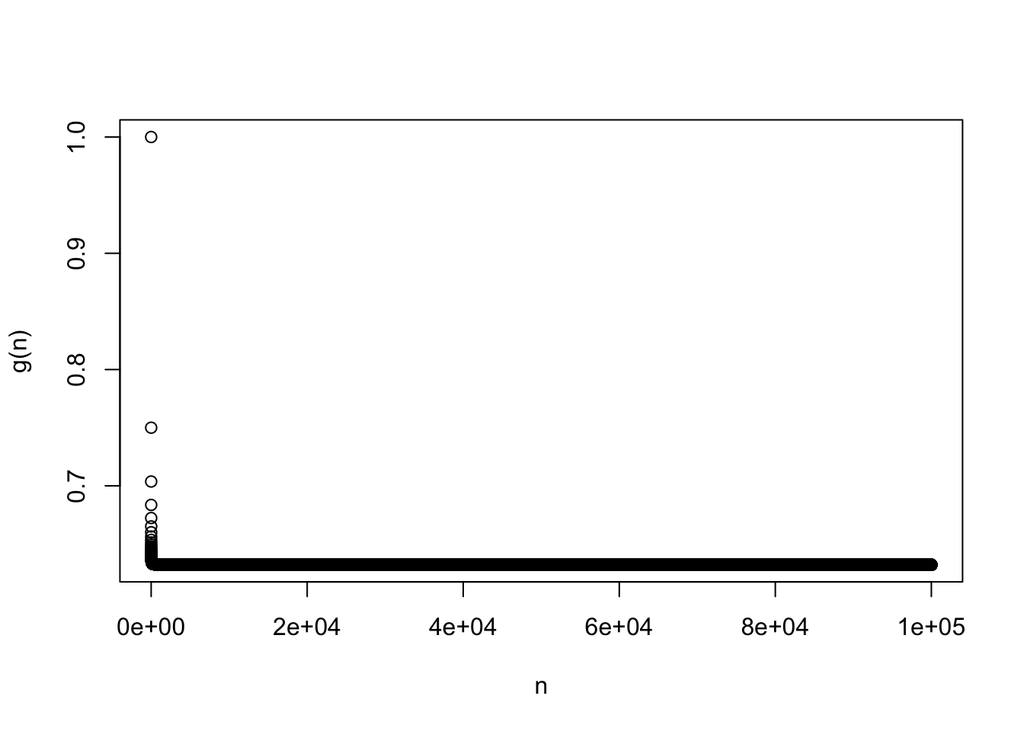

```r
n = 1:10^5
g = function(n){ return(1 - (1 - 1/n)^n)}
plot(n, g(n))
```

## 2.h

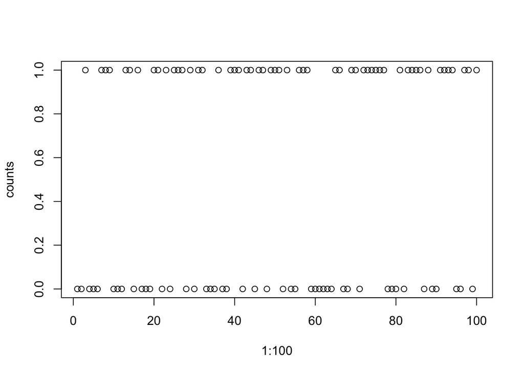

```r
my.data<-c(1:100)
counts <- rep(0, 100)
for(i in 1:100){
  temp<-mosaic::resample(my.data)
  if(4 %in% temp){counts[i]<-1}
}
plot(1:100, counts)
```

```r
print(sum(counts)/100)
```

```
## [1] 0.54
```

## 3.a

```r
data('Weekly', package='ISLR')
model_3a <- glm(I(Direction=='Up') ~ Lag1+Lag2, family = 'binomial', data=Weekly)

Weekly <- Weekly %>%
  mutate(phat = predict(model_3a, type='response'),
         yhat = ifelse(phat > .5, 'Up', 'Down'))
# Calculate the confusion matrix
table( Truth=Weekly$Direction, Predicted=Weekly$yhat )
```

```
##       Predicted
## Truth  Down  Up
##   Down   38 446
##   Up     38 567
```

## 3.b

```r
# starting from the second element
Weekly.train<-Weekly[-1, ]
model_3b <- glm(I(Direction=='Up') ~ Lag1+Lag2, family = 'binomial', data=Weekly.train)

Weekly.train <- Weekly.train %>%
  mutate(phat = predict(model_3b, type='response'),
         yhat = ifelse(phat > .5, 'Up', 'Down'))
# Calculate the confusion matrix
table( Truth=Weekly.train$Direction, Predicted=Weekly.train$yhat )
```

```
##       Predicted
## Truth  Down  Up
##   Down   38 445
##   Up     37 568
```

## 3.c

```r
yhat_3c = ifelse(predict(model_3b, newdata=Weekly[1,], type='response') > .5, 'Up', 'Down')
y_3c = Weekly[1,]$Direction
if( y_3c == yhat_3c){
  print('correctly predicted')
}else{print('not correctly predicted')}
```

```
## [1] "not correctly predicted"
```

## 3.d

```r
LOOCV <-NULL
for(i in 1:nrow(Weekly)){
  #leave one out cross validation
  Weekly.train<-Weekly[-i, ]
  Weekly.test<-Weekly[i, ]
  #train the model
  model_3d <- glm(I(Direction=='Up') ~ Lag1+Lag2, family = 'binomial', data=Weekly.train)
  #predict the test set, calculate posterior proba and then map it to a class
  yhat = ifelse(predict(model_3d, newdata=Weekly.test, type='response') > .5, 'Up', 'Down')
  #compare to the ground truth
  if( Weekly.test$Direction == yhat) LOOCV<-rbind(LOOCV,1)
  else LOOCV<-rbind(LOOCV,0)
}
```

## 3.e

```r
sum(LOOCV)/length(LOOCV)
```

```
## [1] 0.5500459
```

The result is only slightly larger than 0.5. It means that the estimated accuracy is only 50%. This is due to the selection of predictors, the predictors may be incorrelated with the response.

## 4.a

n=100,p=1

$y=x-2x^2+\epsilon$

```r
set.seed (1)
n <- 100
x <- rnorm(n)
y <- x - 2*x^2 + rnorm(n)
data <- data.frame(x=x, y=y)
```

## 4.b

The relationship between predictor and response is nonlinear. According to the model description, the relationship between predictor and response is a second order polynomial, so theoretically a second order polynomial model should fit the data best.

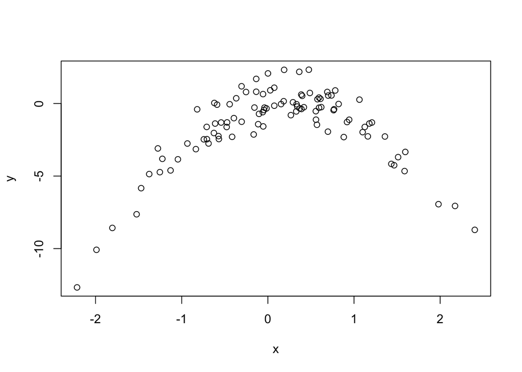

```r
plot(x,y)
```

## 4.c

# i,ii,iii

```r
K = 5
KCV <-NULL
for(i in 1:4){
  data<- data %>%
    mutate(fold = sample( rep(1:5, times=ceiling(100/5))[1:100]  ))
  for(k in 1:K){
    index <- which( data$fold == k )
    train <- data[ -index, ]
    test  <- data[  index, ]
    model <- lm( y ~ poly(x,i), data=train)
    data[index,'yhat']  <- predict(model, newdata=test)
  }
  KCV <- rbind(KCV,data.frame(order=i, K=K, MSE = mean( (data$y - data$yhat)^2 )))
}
KCV
```

```
##   order K       MSE
## 1     1 5 7.4067519
## 2     2 5 0.9548389
## 3     3 5 0.9323871
## 4     4 5 0.9734140
```

## 4.d

It’s different from the result in 4.c. This is because every time when we partition the observations into K non-overlapped subset we randomly generate the index. The seed for generate random number is different for 4.c and 4.d, so we end up with different K subsets, which gives us different results.

```r
K = 5
KCV <-NULL
for(i in 1:4){
  data<- data %>%
    mutate(fold = sample( rep(1:K, times=ceiling(100/K))[1:100]  ))
  for(k in 1:K){
    index <- which( data$fold == k )
    train <- data[ -index, ]
    test  <- data[  index, ]
    model <- lm( y ~ poly(x,i), data=train)
    data[index,'yhat']  <- predict(model, newdata=test)
  }
  KCV <- rbind(KCV,data.frame(order=i, K=K, MSE = mean( (data$y - data$yhat)^2 )))
}
KCV
```

```
##   order K       MSE
## 1     1 5 8.4292006
## 2     2 5 0.9267994
## 3     3 5 1.0403248
## 4     4 5 1.0305926
```

## 4.e

For LOOCV, the results remains the same when repeating the process.

```r
K = 100
for(r in 1:3){
KCV <-NULL
for(i in 1:4){
  data<- data %>%
    mutate(fold = sample( rep(1:K, times=ceiling(100/K))[1:100]  ))
  for(k in 1:K){
    index <- which( data$fold == k )
    train <- data[ -index, ]
    test  <- data[  index, ]
    model <- lm( y ~ poly(x,i), data=train)
    data[index,'yhat']  <- predict(model, newdata=test)
  }
  KCV <- rbind(KCV,data.frame(order=i, K=K, MSE = mean( (data$y - data$yhat)^2 )))
}
print(KCV)
}
```

```
##   order   K       MSE
## 1     1 100 7.2881616
## 2     2 100 0.9374236
## 3     3 100 0.9566218
## 4     4 100 0.9539049
##   order   K       MSE
## 1     1 100 7.2881616
## 2     2 100 0.9374236
## 3     3 100 0.9566218
## 4     4 100 0.9539049
##   order   K       MSE
## 1     1 100 7.2881616
## 2     2 100 0.9374236
## 3     3 100 0.9566218
## 4     4 100 0.9539049
```

## 4.f

For K-fold CV, the second order polynomial (most of the times) model or third order polynomial (sometimes) has the lowest MSE, the same conclusion holds for LOOCV as well. This is expected because the true model which generates this data is a second order polynomial

## 4.g

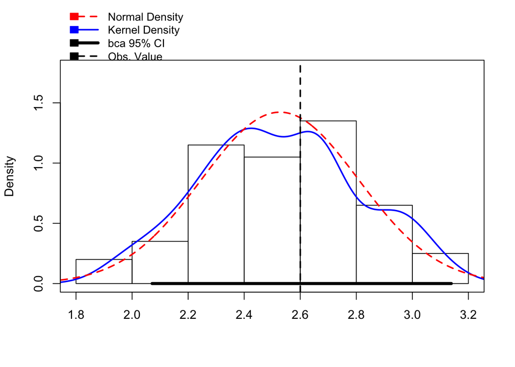

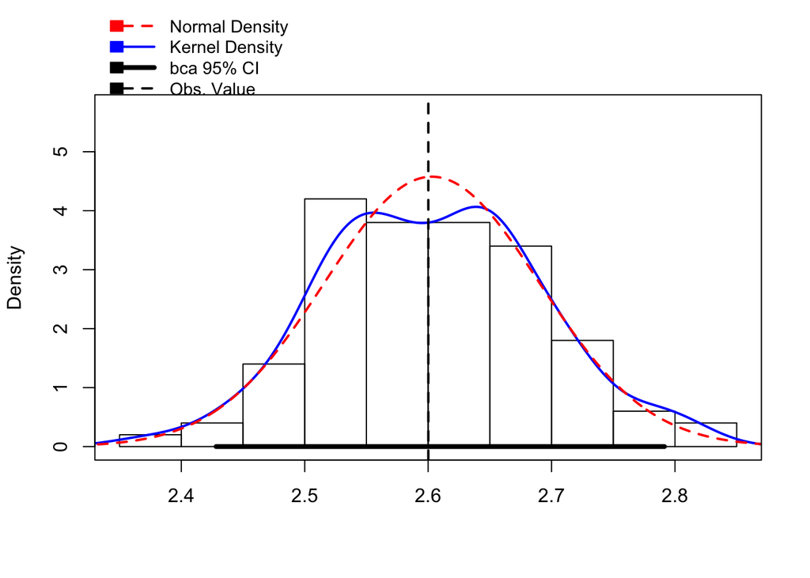

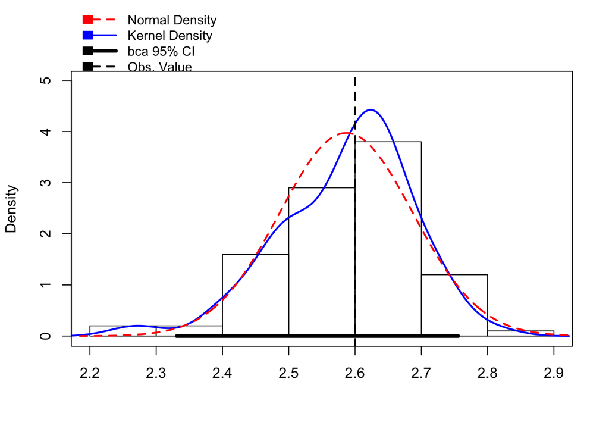

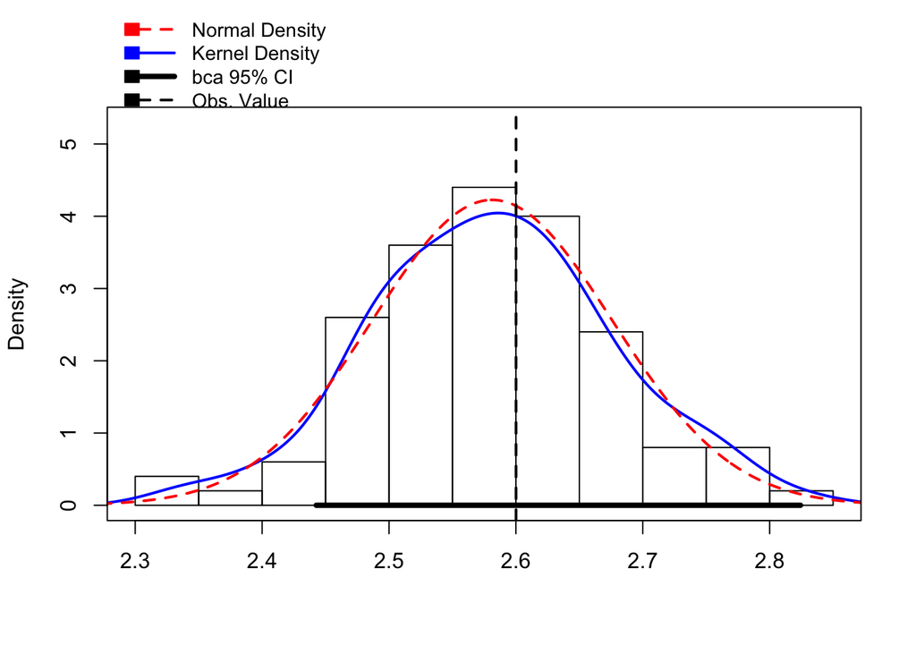

```r
for(i in 1:4){
# Do residual resampling with the regression example
model <- lm( y ~ poly(x,i), data=data )
data <- data %>% mutate(
  fitted = fitted(model),
  resid  = resid(model))

# Define the statisitc I care about
my.stat <- function(sample.data, indices){
  data.star <- sample.data %>% mutate(y = fitted + resid[indices])
  model.star <- lm(y ~ x, data=data.star)
  output <- summary(model.star)$sigma
  return(output)
}

boot.model <- boot(data, my.stat, R=100)
hist(boot.model, layout=c(1,3))
}
```